# Data Science in Practice

Day 1: Data collection

Karl Ho

7/27/2020

# 1 What is data?

Let’s first explore the general theory of data.

1. Kinds of Data
   1. Quantitative vs. Qualitative
   2. Structured vs. Semi-/unstructured
2. Measurement
   1. Nominal
   2. Ordinal
   3. Interval
   4. Ratio

# 2 What is big data?

The Big data is about data that has huge volume, cannot be on one computer. Has a lot of variety in data types, locations, formats and form. It is also getting created very very fast (velocity) (Doug Laney 2001).

According Burt Monroe (2012), the new 5Vs of Big data include:

- Volume
- Variety
- Velocity
- Vinculation
- Validity

Vinculation means “binding together”, indicating emphasizes interdependent nature or “networkedness” of social data and big data.

Validity or veracity refers to the quality of the data and how relevant big data is to the question in interest. In particular, how one can draw inference from big data.

Some researchers would also add “value” to emphasize whether the data provide insight instead of confusion to understanding the problem(s).

## 2.1 Illustration: The story of Google Flu Trend

By using Big Data of search queries, Google Flu Trend (GFT) predicted the flu-like illness rate in a population.

The findings were published in the one of the top science journals *Nature* in 2008. However, shortly GFT failed and missed at the peak of the 2013 flu season by 140 percent.

Lazer, Kennedy, King and Vespignani (2014) took up the scrutiny and identified the problem. They suggested: " “Traditional ‘small data’ often offer information that is not contained (or containable) in big data”, and “by combining GFT and lagged [traditional] CDC data, as well as dynamically recalibrating GFT… one can substantially improve on the performance of GFT or the CDC alone.” (Lazer et al. 2014 *Science*)

Lesson learnt: Google should have highest power in data access but it still fails. Size still matters? Yes, but not first.

# 3 Data Collection

## 3.1 Data Production and Collection

Data can be classified by generation methods into two types: *made* data and *found* data. These methods include:

1. Survey
2. Experiments
3. Qualitative Data
4. Text Data
5. Web Data
6. Machine Data
7. Complex Data
- Network Data
- Multiple-source linked Data

The first three methods are considered made or produced data, which go through a well-thought out design process, and data are generated by an instrument or human interviews. These methods usually go through a sampling or pre-selection mechanism, in order that the data will represent the population to a certain extent. The remaining methods are called found or collected data that are primarily extracted from other sources without an intrument or a design process. The sampling mechanism is not pre-designed and usually subject to the property of the extraction algorithm.

Some researchers called the former type or made data as small data and the latter the big data. Statistian Leo Breiman (2001) describe these two types of data as two cultures of statistical modeling.

## 3.2 Data collection showcase: Twitter data

### 3.2.1 APIs (Application program interface)

- API provides channels to allow an interaction with, and retrieval of, structured data.
- Many data companies such as Facebook, Twitter and public and private organizations provide APIs for developers or users to access data directly.
- API methods however limit users to get the data according to the company’s restrictions.

### 3.2.2 Webscraping

- this method generally refers to using algorithm or simple program to obtain information directly from web pages.
- data collected using this methods is generally raw and unstructured, meaning more data curation and clean-up are needed before data can be used.

The following chart from Munzert et al. (2015) illustrates the technologies of dealing with web data:

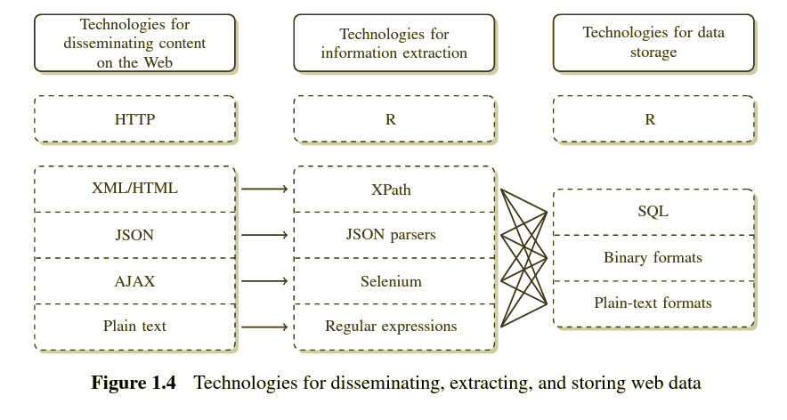

Source: Munzert et al. 2015.*Automated Data Collection with R: a Practical Guide to Web Scraping and Text Mining*

### 3.2.3 Hands-on workshop: collecting Twitter data

This workshop uses Python to collect Twitter data using a package by [Jefferson Henrique](https://github.com/Jefferson-Henrique/GetOldTweets-python) and [Dimtry Mottl](https://github.com/Mottl/GetOldTweets3). This non-API method scrapes Twitter data based on Twitter search results by parsing the result page with a scroll loader, then calling to a JSON provider (i.e. collect data in json format). While theoretically it can search through oldest tweets and collect data accordingly, the number of variables are limited to the layout of search results.

Mac | Windows

#### 3.2.3.1 *Mac*

Prerequesites:

1. Python3
2. Bash/terminal command line tool
3. Python pip package installer

Illustration using [GetOldTweets3](https://pypi.org/project/GetOldTweets3/) Install Python 3.x (e.g. Anaconda3) and run the following preparation steps (creating virtual environment, install GetOldTweets3 package using pip):

```bash
python3 -m venv env
source ./env/bin/activate
python3 -m pip install GetOldTweets3
```

Alternatively,

```bash
pip install -e git+https://github.com/Mottl/GetOldTweets3#egg=GetOldTweets3
```

There are two methods of collecting Twitter data. The GetOldTweets3 command method is recommended since the data collection process can be time-consuming.

Examples:

```bash
## Keyword search
GetOldTweets3 --querysearch "Trump Kim" --since 2018-01-01 --until 2019-01-16 --output trumpkim.csv

## username search with time period and size limit
GetOldTweets3 --username "realDonaldTrump" --since 2016-11-01 --until 2019-03-08 --maxtweets 20000 --output rdt_2016_now.csv
```

#### 3.2.3.2 *Windows*

The following procedures are for Windows users (Python2.x or Python 3.x):

Prerequisites

1. Python installed
- Install Anaconda Navigator (http://anaconda.com)
- Install Python3.x from python.org
2. Visit the following github by Nickson Weng and download the Python package Get-Old_Tweet-Modified

https://github.com/NicksonWeng/Get-Old-Tweet-Modified

1. Click on the “Clone or Download” green button on right side
2. Download ZIP to local folder (e.g. c:\Twitterdata)
3. Unzip the files to the folder
2. Open a terminal windows by typing terminal in the “Type here to search” box. Choose the Command Prompt App
3. Change directory to c:\Twitterdata
4. Type:

pip install -r requirements.txt

Perform search using the following criteria (username or keyword)

Examples:

```bash
## Keyword search
python Exporter.py --querysearch "impeach" --maxtweets 1000 --output impeach.csv

## username search with time period and size limit
python Exporter.py --username "realDonaldTrump" --maxtweets 100 --output dt_100.csv
```

For Python 3.x, replace Exporter.py with Exporter_py3.py